# Title: Reproducible Research

I split this assignment into two parts.

This (second) program produces the analyis for data with the NAs replaced by the average for that interval over the two months. The program name is ‘prog_02.Rmd’ with corresponding ‘prog_02.html’ file.

The first program produces the analysis of the data with the NA values omitted. The program name is ‘prog_01.Rmd’ with corresponding ‘prog_01.html’ file. =========================================================================

```r
    library(dplyr)
```

```r
    library(knitr)
    library(ggplot2)

    act_01   <-    read.csv("activity.csv", header=TRUE)
    summary(act_01)
```

```
##      steps                date          interval
##  Min.   :  0.00   2012-10-01:  288   Min.   :   0.0
##  1st Qu.:  0.00   2012-10-02:  288   1st Qu.: 588.8
##  Median :  0.00   2012-10-03:  288   Median :1177.5
##  Mean   : 37.38   2012-10-04:  288   Mean   :1177.5
##  3rd Qu.: 12.00   2012-10-05:  288   3rd Qu.:1766.2
##  Max.   :806.00   2012-10-06:  288   Max.   :2355.0
##  NA's   :2304     (Other)   :15840
```

```r
    head(act_01)
```

```
##   steps       date interval
## 1    NA 2012-10-01        0
## 2    NA 2012-10-01        5
## 3    NA 2012-10-01       10
## 4    NA 2012-10-01       15
## 5    NA 2012-10-01       20
## 6    NA 2012-10-01       25
```

```r
    NROW(act_01)
```

```
## [1] 17568
```

```r
    tail(act_01, n= 5, addrownums)
```

```
##       steps       date interval
## 17564    NA 2012-11-30     2335
## 17565    NA 2012-11-30     2340
## 17566    NA 2012-11-30     2345
## 17567    NA 2012-11-30     2350
## 17568    NA 2012-11-30     2355
```

Imputing missing values

Note that there are a number of days/intervals where there are missing values (coded as NA). The presence of missing days may introduce bias into some calculations or summaries of the data.

Calculate and report the total number of missing values in the dataset (i.e. the total number of rows with NAs)

Devise a strategy for filling in all of the missing values in the dataset. The strategy does not need to be sophisticated. For example, you could use the mean/median for that day, or the mean for that 5-minute interval, etc.

Create a new dataset that is equal to the original dataset but with the missing data filled in.

Comments: I replaced all the missing values with the average for that particular interval.

================================================================================

```r
    missing_steps <- filter(act_01, is.na(steps)==TRUE)
    summary(missing_steps)
```

```
##      steps              date        interval
##  Min.   : NA    2012-10-01:288   Min.   :   0.0
##  1st Qu.: NA    2012-10-08:288   1st Qu.: 588.8
##  Median : NA    2012-11-01:288   Median :1177.5
##  Mean   :NaN    2012-11-04:288   Mean   :1177.5
##  3rd Qu.: NA    2012-11-09:288   3rd Qu.:1766.2
##  Max.   : NA    2012-11-10:288   Max.   :2355.0
##  NA's   :2304   (Other)   :576
```

```r
    NROW(missing_steps)
```

```
## [1] 2304
```

```r
    head(missing_steps)
```

```
##   steps       date interval
## 1    NA 2012-10-01        0
## 2    NA 2012-10-01        5
## 3    NA 2012-10-01       10
## 4    NA 2012-10-01       15
## 5    NA 2012-10-01       20
## 6    NA 2012-10-01       25
```

```r
    tail(missing_steps)
```

```
##      steps       date interval
## 2299    NA 2012-11-30     2330
## 2300    NA 2012-11-30     2335
## 2301    NA 2012-11-30     2340
## 2302    NA 2012-11-30     2345
## 2303    NA 2012-11-30     2350
## 2304    NA 2012-11-30     2355
```

```r
    averages <- aggregate(x =list(steps=act_01$steps),
                          by=list(interval=act_01$interval),
                          FUN=mean, na.rm=TRUE)

    fill.value <- function(steps, interval) {
    filled <- NA
    if (!is.na(steps))
        filled <- c(steps)
    else
        filled <- round(averages[averages$interval==interval, "steps"])
    return(filled)
}
    act_02 <- act_01
    act_02$steps <- mapply(fill.value, act_02$steps, act_02$interval)
    summary(act_02)
```

```
##      steps                date          interval
##  Min.   :  0.00   2012-10-01:  288   Min.   :   0.0
##  1st Qu.:  0.00   2012-10-02:  288   1st Qu.: 588.8
##  Median :  0.00   2012-10-03:  288   Median :1177.5
##  Mean   : 37.38   2012-10-04:  288   Mean   :1177.5
##  3rd Qu.: 27.00   2012-10-05:  288   3rd Qu.:1766.2
##  Max.   :806.00   2012-10-06:  288   Max.   :2355.0
##                   (Other)   :15840
```

```r
    head(act_02)
```

```
##   steps       date interval
## 1     2 2012-10-01        0
## 2     0 2012-10-01        5
## 3     0 2012-10-01       10
## 4     0 2012-10-01       15
## 5     0 2012-10-01       20
## 6     2 2012-10-01       25
```

```r
    NROW(act_02)
```

```
## [1] 17568
```

```r
    tail(act_02, n= 50, addrownums)
```

```
##       steps       date interval
## 17519    46 2012-11-30     1950
## 17520    34 2012-11-30     1955
## 17521    20 2012-11-30     2000
## 17522    19 2012-11-30     2005
## 17523    19 2012-11-30     2010
## 17524    33 2012-11-30     2015
## 17525    27 2012-11-30     2020
## 17526    21 2012-11-30     2025
## 17527    27 2012-11-30     2030
## 17528    21 2012-11-30     2035
## 17529    20 2012-11-30     2040
## 17530    21 2012-11-30     2045
## 17531    32 2012-11-30     2050
## 17532    20 2012-11-30     2055
```

[output cut: 36 more lines]

```r
    act_03 <- aggregate(steps ~ date, act_02, sum)

    colnames(act_03) <- c("date","steps")

    head(act_03)
```

```
##         date steps
## 1 2012-10-01 10762
## 2 2012-10-02   126
## 3 2012-10-03 11352
## 4 2012-10-04 12116
## 5 2012-10-05 13294
## 6 2012-10-06 15420
```

```r
    NROW(act_03)
```

```
## [1] 61
```

[figure not shown]

```r
    paddy_01 <- ggplot(data=act_03, aes(act_03$steps)) +
                geom_histogram(breaks=seq(0, 21000, by = 1000),
                 col="Blue",
                 fill="Yellow",
                 alpha = 1) +
  labs(title="Histogram for Steps (NA replaced with the average for that interval") +
  labs(x="Steps", y="Count") +
  xlim(c(0,21000)) +
  ylim(c(0, 11))

    paddy_01 + theme(axis.text.x = element_text(face="bold", color="#993333",
                           size=14, angle=45),
                     axis.text.y = element_text(face="bold", color="#993333",
                           size=14, angle=45))
```

```r
    round(mean(act_03$steps) )
```

```
## [1] 10766
```

```r
    median(act_03$steps)
```

```
## [1] 10762
```

Comments: There is a marked difference between the weekday and weekend activity. The weekday data matched the rythym of a workday activity. The weekend activity shows more spread out over the whole day. ======================================================================

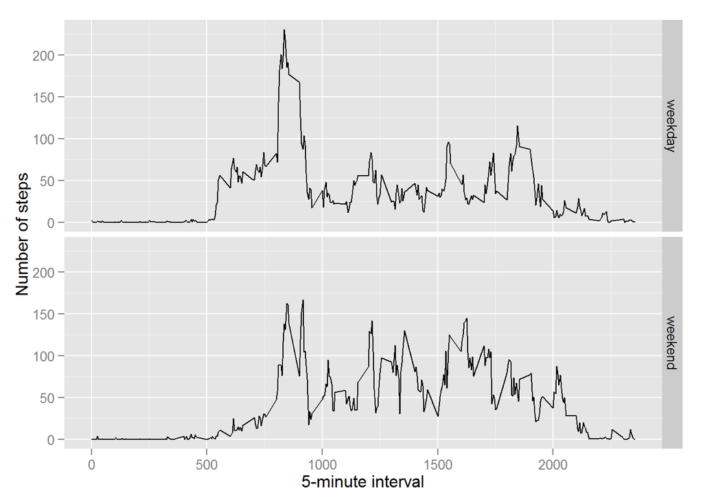

```r
## ------------------------------------------------------------------------
weekday.or.weekend <- function(date) {
    day <- weekdays(date)
    if (day %in% c("Monday",
                   "Tuesday",
                   "Wednesday",
                   "Thursday",
                   "Friday"))
            return("weekday")

    else if (day %in% c("Saturday",
                        "Sunday"))
        return("weekend")
    else
        stop("invalid date")
}
act_02$date <- as.Date(act_02$date)
act_02$day  <- sapply (act_02$date, FUN=weekday.or.weekend)


## ------------------------------------------------------------------------
averages <- aggregate(steps ~ interval + day, data=act_02, mean)
ggplot(averages, aes(interval, steps)) + geom_line() + facet_grid(day ~ .) +
    xlab("5-minute interval") + ylab("Number of steps")
```

The end of the world is nigh………..!!!!!!!!!!!!!!!!!!!